# Linear transformations

## Linear transformations on data

When you have some data ($X$; note you can transform a single value, or a *set* of values) that you want to transform (e.g., converting yards to feet, grades based on 16 questions to grades based on a 100 pt scale), you can use linear transformations to convert your old data ($X_{old}$) into new transformed data ($X_{new}$) with the following formula:

$X_{new} = a + bX_{old}$

Here, $a$ and $b$ are constants (e.g., $a$ could equal 0, and $b$ could equal 1). Imagine we have some set of values, $X$, that is equal to $4, 8, 12$, with a mean ($\bar{x} \text{ or } mean(X) = 8$). Adding/subtracting a constant $a$ from the data will add/subtract $a$ from each value to obtain the transformed data (e.g., if we add $a = 2$, then our transformed data, $Y$, $= 6, 10, 14$); in order to calculate the mean of the transformed data, we can use the following equation:

$mean(Y) = a + b*mean(X)$

Where, in this case $b=1$ since we’re just adding $a$ to $X$. Thus, we have $mean(Y) = 2 + 1*mean(X)$, and subsituting in the mean, we can solve it: $mean(Y) = 2 + 1*8 = 10$, which is indeed the mean of the set of numbers $6, 10, 14$!

Similarly we could scale the data by multiplying each value by a constant $b$. According to the equation above, we could calculate the mean of our new data $Y$ by multiplying our old mean ($\bar{x} \text{ or } mean(X) = 8$) by $b$, and then adding $a$ (which could be 0!). Let’s walk through a quick example where our initial data is measurements in yards, and we want to convert those to feet by multiplying them by $b$ = 3 feet/yard. Again, using the equation above, we should be able to estimate the mean of our transformed data by multipying the mean of our old data by $b$:

```r
yards = c(4,8,12) # this is X!
m_yards = mean(yards); m_yards
```

```
## [1] 8
```

```r
m_yards * 3  # our estimate for mean of the new data Y (in feet)
```

```
## [1] 24
```

```r
feet = yards * 3; feet # this is Y!
```

```
## [1] 12 24 36
```

```r
m_feet = mean(feet); m_feet # same thing as above!
```

```
## [1] 24
```

We can also estimate the variance and standard deviation of our new transformed data using similar formulas:

$var(Y) = b^2*var(X)$ $s.d.(Y) = b*s.d.(X)$

Let’s try this with our data converting yards to feet:

```r
var_yards = var(yards)
sd_yards = sd(yards)

var_feet = var(feet); var_feet
```

```
## [1] 144
```

```r
var_yards*3^2 #using formula: var(Y) = b^2*var(X)
```

```
## [1] 144
```

```r
sd_feet = sd(feet); sd_feet
```

```
## [1] 12
```

```r
sd_yards * 3  #using formula: s.d.(Y) = b*s.d.(X)
```

```
## [1] 12
```

### Look at this graphically

If we had more samples (500!), we could see what this might look like graphically. Here, we have data in yards, with a mean of 8, and sd of 4. Transforming this data into feet (by multiplying by $k$ = 3), we can see that the mean is scaled from 8 to 24 (by a factor of 3), and the standard deviation is also scaled by a factor of 3 (note that the data in feet is much more spread out).

```
## New standard deviation:  11.59
```

```
## stat_bin: binwidth defaulted to range/30. Use 'binwidth = x' to adjust this.
```

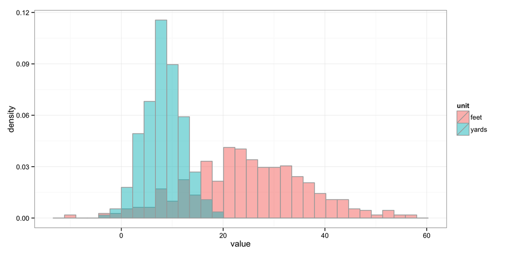

## Linear transformations on statistics

As noted above, sometimes you might want to transform a single value, or in some cases, a **statistic**. Remember that a statistic is something that is *estimated* from a sample (e.g., the sample mean, $\bar{x}$) – not from the true population – and so, there’s some degree of *uncertainty* about these estimates.

A mean taken from a **sample** ($\bar{x}$) is just an *estimation* of the population mean $\mu$ (since we don’t know the true mean of the broader population); you can take different samples from the same population, and get different values of the sample mean $\bar{x}$, sample standard deviation ($s$) and sample variance ($s^2$). Importantly, if you take a few samples from the population, the distribution of *sampled means* can have *its own* mean, variance, and standard deviation. Here, the standard deviation of these sample means is referred to as the **standard error of the mean (SEM)** – it can be considered as the standard deviation of the error in the sample mean with respect to the true population mean – effectively using the sample mean to *estimate* the population mean. The SEM is estimated using this formula:

$SE_{\bar{x}} = \frac{s}{\sqrt{n}}$

where $s$ is the sample standard deviation, and $n$ is the sample size.

Turning to the example from the homework (1.b), we have a **sample** of maltreatment deaths from 6 years (here, the population is all the years, and we’re assuming that the frequency of maltreatment deaths is the same every year). To estimate the mean number of deaths in a given year, we find the mean ($\bar{x}$) of this sample:

```r
X = c(11, 15, 15, 16, 25, 20)
xbar = mean(X); xbar
```

```
## [1] 17
```

Now, we can calculate the **standard deviation of this sample**:

```r
sd_sample = sd(X)
```

```r
se_xbar = sd_sample/sqrt(length(X)); se_xbar
```

```
## [1] 1.983
```

Then, we might be interested in linearly transforming our statistic $\bar{x}$, for instance, to estimate the total number of deaths in $k$ years. Here, we can apply the same formulae from above, specifically:

$mean(Y) = a + b*mean(X)$ $var(Y) = b^2*var(X)$ $s.d.(Y) = b*s.d.(X)$

Now, $X$ = $\bar{x}$, $a=0$, $b=k$, and $Y =$ total number of deaths in $k$ years = $T$. Here, the **standard deviation of our statistic** (e.g., $T$ or $\bar{x}$) can be obtained using our formula for the **standard error**. That’s because there’s some error in the sample mean’s estimation of the population mean (the true number of deaths in a given year), and this standard deviation in the estimation of the sample mean is estimated with standard error! As a result, our standard deviation of $\bar{x}$ = the standard error of $\bar{x}$, and we just need to multiply that by $k$ to estimate the standard deviation of $T$:

```r
# for k=3 years
k = 3
sd_Y = k*se_xbar; sd_Y
```

```
## [1] 5.95
```

So the standard deviation of $T$ is that of $\bar{x}$ scaled by $k$.